# NCBN Salt Marsh Vegetation Monitoring Protocol Review

#### **1. Introduction**

##### **1.1** The NCBN Salt Marsh Vegetation Monitoring Protocol

The National Park Service Inventory and Monitoring (I&M) Program’s Northeast Coastal and Barrier Network (NCBN) has identified salt marsh condition, in addition to several associated vital signs, as a high priority for long-term monitoring. The first iteration of the salt marsh vegetation monitoring protocol was originally developed by the USGS and University of Rhode Island for the purpose of comparing the vegetation community in hydrologically altered marshes to more pristine ‘control’ marshes in order to understand the potential effects of hydrologic restoration on salt marsh habitats within Cape Cod National Seashore (Roman et al., 2001). This protocol was then adapted to measure change in the species composition and abundance of the salt marsh plant community at the other six coastal parks monitored by NCBN in response to a multitude of stressors such as hydrologic alteration, storms, visitor use, nutrient loading, watershed development, sea-level rise and climate change, among others (Rocks and Stevens 2018). The salt marsh vegetation monitoring protocol was successfully implemented across seven NCBN parks over a period of 10 years from 2008 to 2018, but was placed on hold in 2018 due to staffing and budget shortages. To date, only a single analysis of the existing data has been conducted (Peck et al. 2021). However, this previous analysis examined only a subset of the data collected for this protocol and does not include many of the trend analyses that may be applicable to resource management in the parks. Since this protocol was put on hold in 2018, resource management staff at several parks in the NCBN network have expressed interest in both the results of the previous monitoring efforts and in continued salt marsh vegetation monitoring at their respective parks. Thus, the objectives of this report are: a) identify limitations of the current protocol and previous analyses conducted by Peck et al. (2021); b) provide additional analysis of the existing data and interpretation of the results that may be useful to the parks’ resource management staff; and c) discuss alternative methods for continued monitoring of salt marsh vegetation in the parks.

##### **1.2** Limitations of the Current Protocol

During the years that this protocol was active, it was by far the most labor- and time-intensive vital sign monitored by NCBN. For instance, assuming a four person crew (two full-time biologists and two interns) was used for each sampling event, a conservative estimate of 7,072 total man-hours were dedicated to field data collection alone during this time (i.e., 221 sampling events *x* 8 hours per day *x* 4 crew members). Further more, this estimate does not include the additional time needed for traveling to and from the NCBN main office (Kingston, Rhode Island) to each park, logistical considerations (e.g., time for budget and travel planning, equipment preparation, clean-up, etc.), or data management and annual reporting tasks, among others. For a more specific example, it took a total of 13 full days to complete field sampling at just 1 park - ASIS - in 2018. Similarly, this protocol was also one of the more budget intensive monitoring programs conducted by NCBN. In 2018, Rocks and Stevens (2018) estimated that the annual operational cost associated with the NCBN salt marsh vegetation monitoring protocol was $50,000 per year - a figure that would likely be much higher today. Thus, budget and staffing shortages represent a major impediment to continuing the field data collection procedures outlined in the existing protocol.  
The data summaries that were suggested for annual reporting in the protocol implementation plan (Rocks and Stevens 2018) include species composition (species lists), percent cover for all cover types by site, and presence of any federal, state-listed and/or non-native species. Additionally, the protocol implementation plan also recommends that trend analysis be conducted on a 3-5 year basis and suggests the use of non-parametric multivariate community analysis methods such as analysis of similarities (ANOSIM) and similarity of percentages analysis (SIMPER) in order to understand change over time. The suggestion to include species lists for annual reporting are necessary in order to have a record of the full suite of species at each park and the compilation of these lists is relatively straightforward and easy to interpret. However, the recommended trend analysis (ANOSIM and SIMPER) do not actually calculate trends and only indicate where differences between plant communities have occurred in the previous sample years. As such, these methods of analysis have limited value for understanding the broader ‘big-picture’ changes in these salt marsh plant communities and also do not provide a means for predicting future changes and developing management actions that may be needed to either counteract or facilitate these changes.

##### **1.3** Limitations of Previous Analyses

In 2021, NCBN commissioned a report by Neptune and Company (hereafter referred to as Peck et al. 2021) that evaluates the sampling power of the salt marsh vegetation and nekton monitoring protocols and summarizes trends within a limited subset of the metrics collected as part of these protocols. For the vegetation protocol, the metrics of interest were a multimetric index (MMI) of salt marsh condition developed by Nagel et al. (2017), as well as individual metrics of community composition including the percent cover of Spartina patens and percent cover of high salinity plant species. Power simulations were performed to assess whether the data collected to date were sufficient to detect trends in either the multimetric index or previously listed individual metrics given the large amount of staff time and program money being spent on these protocols. Trends in the multimetric index and the two selected individual metrics for the period of 2008 to 2018 were also quantified using regression analyses. In this section, we have summarized the findings of Peck et al. (2021) and identified limitations of the study that could potentially be addressed by performing additional analyses on the existing data from 2008-2018.

Although Peck et al. (2021) has value as both an assessment of the protocol’s sampling frequency and intensity and as an initial exploratory data analysis, there are large amounts of data that were collected for the salt marsh vegetation monitoring protocol that were not examined in the report. For example, the protocol necessitates recording the presence and cover of every individual species found in every plot, but only a few species are used in the analyses. As such, the analyses contained within Peck et al. (2021) did not consider changes within the context of either a) ecologically significant groups that are known to characterize these habitats, or b) the entire full, comprehensive suite of species that comprise these communities. Given the multivariate nature of the data and the protocol’s focus on monitoring change in biological communities over time, we have identified several analyses that could aid in interpreting and drawing conclusions from the existing 2008-2018 data set in the following sections.

#### **2. Methods**

##### **2.1** Details of Park-Specific Sampling Schemes

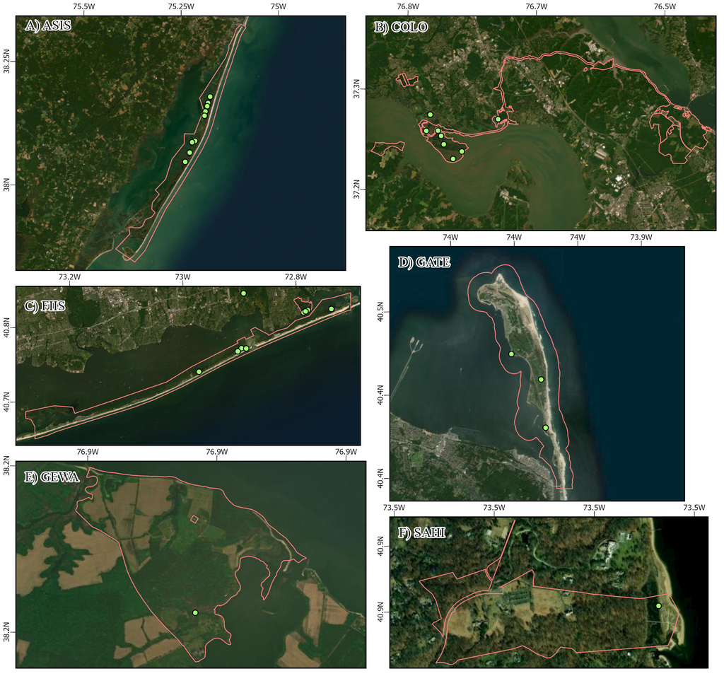

| Table 1. Site count, plot count, monitoring years, and count of sampling events at each park utilizing the NCBN salt marsh vegetation monitoring protocol. Park Unit | Table 1. Site count, plot count, monitoring years, and count of sampling events at each park utilizing the NCBN salt marsh vegetation monitoring protocol. Unit Code | Table 1. Site count, plot count, monitoring years, and count of sampling events at each park utilizing the NCBN salt marsh vegetation monitoring protocol. Location | Table 1. Site count, plot count, monitoring years, and count of sampling events at each park utilizing the NCBN salt marsh vegetation monitoring protocol. Number of Sites | Table 1. Site count, plot count, monitoring years, and count of sampling events at each park utilizing the NCBN salt marsh vegetation monitoring protocol. Site List | Table 1. Site count, plot count, monitoring years, and count of sampling events at each park utilizing the NCBN salt marsh vegetation monitoring protocol. Number of Plots | Table 1. Site count, plot count, monitoring years, and count of sampling events at each park utilizing the NCBN salt marsh vegetation monitoring protocol. Sample Years | Table 1. Site count, plot count, monitoring years, and count of sampling events at each park utilizing the NCBN salt marsh vegetation monitoring protocol. Sampling Events |
| --- | --- | --- | --- | --- | --- | --- | --- |
| Assateague Island National Seashore | ASIS | MD, VA | 9 | A10, A11, A2, A3, A4, A5, A6, A8, A9 | 2,125 | 2008, 2010, 2012, 2014, 2016, 2018 | 6 |
| Colonial National Historical Park | COLO | VA | 8 | C1, C13, C19, C23, C30, C5, C6, C8 | 1,043 | 2008, 2010, 2012, 2014, 2016 | 5 |
| Fire Island National Seashore | FIIS | NY | 9 | F1, F2, F3, F4, F5, F6, WF1, WF2, WF3 | 2,395 | 2009, 2011, 2013, 2015, 2017 | 5 |
| Gateway National Recreation Area | GATE | NJ, NY | 3 | GSH1, GSH2, GSH3 | 413 | 2010, 2012, 2014, 2016, 2018 | 5 |
| George Washington Birthplace National Monument | GEWA | VA | 1 | G1 | 140 | 2008, 2010, 2012 | 3 |
| Sagamore Hill National Historic Site | SAHI | NY | 1 | SAG1 | 225 | 2009, 2011, 2013, 2015, 2017 | 5 |

##### **2.2** Additional Analyses of the 2008-2018 Data

We compared changes in the salt marsh plant community over time within the 6 park units using the following 5 metrics: average total plot cover, average plot-level species richness, maximum plot-level species richness, total park-level species richness, and the number of species unique to each park. Average plot-level species richness represents the average number of species recorded in each plot. Maximum plot-level species richness was derived from the plot with the highest species richness found among all plots at each park. Total park-level species richness was calculated as the total number of distinct species found across all plots at each park. The number of unique species at each park represents the count of species at a park that were not found at the other 5 parks. For average total plot cover, average plot-level species richness, and maximum plot-level species richness, we first calculated the value of each metric for each plot within each site for each year, and then averaged these plot-level values up to the site-level for each year. Comparisons over time within each park are presented as line graphs with the sample years on the x-axis and the respective metric on the y-axis, with separate panels for each park unit. Error values and error bars represent the standard error of the site-level yearly values for the 5 previously mentioned metrics.  
For the species present in each park, we identified any species that were classified as either threatened or endangered at the federal level or considered rare by the respective state where each park was located. Additionally, we also identified any species that were considered invasive, noxious, or prohibited by each respective state. Sources for these state-level rare and/or invasive species are provided in Appendix 1.  
Since salinity is known to be a key factor controlling plant community composition in coastal wetlands, we also compared changes over time in the count, frequency, and percent cover of species with low, medium, and high salinity tolerance at each park. We used the salinity tolerance categories from the USDA plants database to categorize each species as either low (< 0.5 ppt), medium (0.5 to 18 ppt), or high (> 18 ppt) salinity tolerance. Note that there were several species (47 out of 156) that did not have salinity tolerance classifications in the USDA plants database. Salinity tolerance categories for each species are shown in Appendix 2. For each park, we describe which salinity tolerance categories had either a change in species count greater than 2, a change in the frequency of occurrence greater than 0.05, or a change in percent cover greater than 10% between the beginning and end of the sampling period.  
Similarly, we also compared changes over time in the count, frequency, and percent cover of species in eight distinct community classes at each park. The eight community classes included freshwater wetland, salt marsh, salt marsh open ditch, salt marsh plugged ditch, salt marsh pool/panne, salt marsh shoreline, tidal creek, and tidal lagoon. Note that there were several species (44 out of 156) that had not been assigned to a community class. The community classification for each species is shown in Appendix 2. For each park, we describe which community classes had either a change in species count greater than 2, a change in the frequency of occurrence greater than 0.05, or a change in percent cover greater than 10% between the beginning and end of the sampling period.  
Finally, we compared changes in plant community composition over time at each park using permutational multivariate analysis of variance using distance matrices (ADONIS) via the ‘adonis2’ function from the R package ‘vegan.’ Although an analysis of similarities (a.k.a. ANOSIM) was recommended for trend analysis in the original NCBN salt marsh vegetation monitoring protocol, we opted to use the ADONIS model since ANOSIM can potentially confound the differences between groups with the dispersion within groups (Warton et al., 2012). For parks where the ADONIS model detected a significant difference between years, we used post-hoc pairwise comparisons with Benjamini and Hochberg corrections (Benjamini and Hochberg 1995) via the function ‘pairwise.adonis’ in the R package ‘pairwiseAdonis’ to find the year-pairs with significant differences. Finally, we used the ‘kruskal.test’ function from the R package ‘stats’ to find the species with significantly different percent cover for the year pairs identified in the previous pairwise comparisons.

#### **3. Results**

##### **3.1** Total Cover

Average total plot cover decreased over the study period at all parks, although the decrease in total cover was more pronounced at some parks than others (Figure 2). For example, at FIIS and GEWA, total plot cover declined substantially between the first sampling event to the last sampling event and showed no signs of recovery (Figure 2c and 2e). Alternatively, total plot cover at ASIS, COLO, GATE, and SAHI declined from the beginning of the study period and appeared to reach a low in 2014, 2012, 2016, and 2015 (respectively), but then appeared to recover during the following sampling events (Figure 2a 2b, 2d, and 2f).

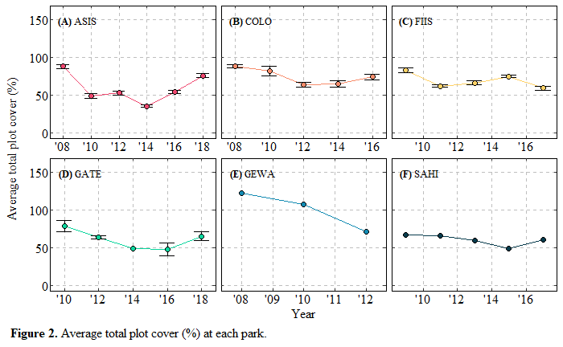

##### **3.2** Species Richness

In total, we identified 156 unique plant species within the salt marshes at all 6 parks. Average plot-level species richness varied little from year to year at all parks throughout the study period (range: 1.2 to 3.6 species per plot) (Figure 3). Maximum plot-level species richness decreased across the entire study period at all parks except COLO and GATE (Figure 3). At COLO, maximum plot-level species richness declined from 7 in 2008 to 6 in 2012, but then increased back to 7 in 2016 (Figure 3b). At GATE, maximum plot-level species richness doubled from 5 in 2014 to 10 in 2018 (Figure 3d). Notably, maximum plot-level species richness at FIIS increased from 7 in 2009 to 9 in 2015 before decreasing substantially to 6 in 2017 (Figure 3c). The species with the top five cover, frequency of occurrence, and importance values at each park are shown in Appendix 3.

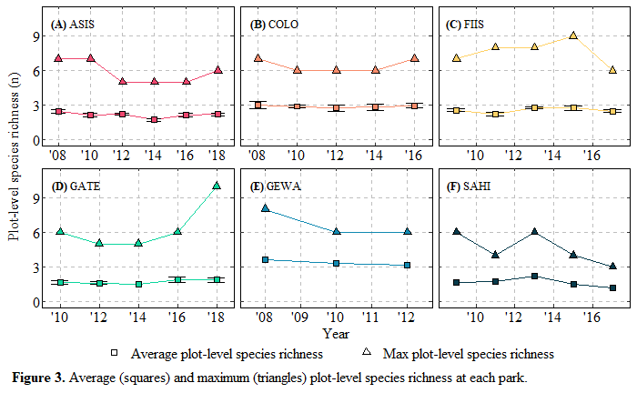

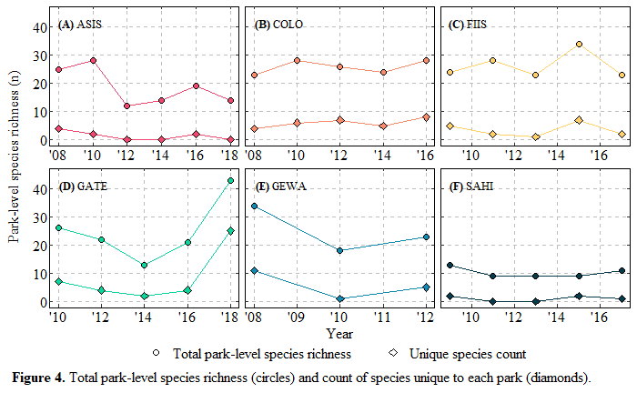

##### **3.4** Invasive, Noxious & Prohibited Species

Of the 156 unique species identified across all parks, 7 were considered invasive, noxious, or prohibited within their respective states. No invasive species were found in ASIS, GEWA, or SAHI. At COLO, only 1 species - *Najas minor* - was considered invasive by the Virginia Department of Conservation and Recreation (https://www.dcr.virginia.gov/natural-heritage/invsppdflist). At FIIS, 3 species, including *Elaeagnus umbellata*, *Phragmites australis*, and *Polygonum perfoliatum*, were considered invasive by the state of New York (State of New York, 2022). At GATE, 4 species, including *Artemisia vulgaris*, *Lonicera japonica*, *Phragmites australis*, and *Rubus phoenicolasius* were considered invasive by the state of New York (State of New York, 2022). Notably, *Phragmites australis* was found in multiple years at both FIIS and GATE (Figure 5b). Of the 7 invasive species found, 4 species were found in only 1 year, including *Najas minor* at COLO in 2016, *Elaeagnus umbellata* and *Polygonum perfoliatum* at FIIS in 2015, and *Rubus phoenicolasius* at GATE in 2018. At FIIS, the average cover of *Phragmites australis* declined from 6% in 2009 to 2% in 2017 (Figure 5a). Similarly, at GATE, the average cover of *Phragmites australis* declined from 5% in 2012 to 1% in 2016 (Figure 5b). Also at GATE, the average coverage of *Artemisia vulgaris* increased from 0% in 2014 to 2% in 2018 (Figure 5b). Similarly, the average cover of *Lonicera japonica* at GATE increased from 0% in 2012 to 0% in 2018 (Figure 5b).

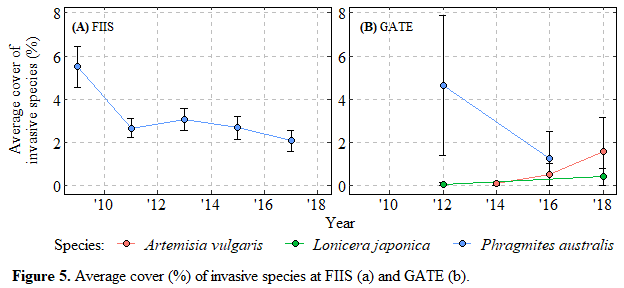

##### **3.5** Salinity Tolerance

##### *3.5.1* Salinity Tolerance: ASIS

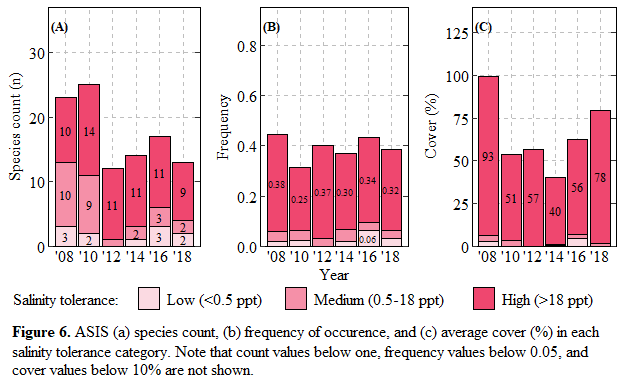

##### *3.5.2* Salinity Tolerance: COLO

At COLO, the count of species in all salinity tolerance categories remained stable between 2008 to 2016 (Figure 7a). However, both the frequency of occurrence and average relative cover of species with low and medium salinity tolerance increased substantially whereas the frequency and cover of species with high salinity tolerance decreased over the same time period (Figure 7b and c).

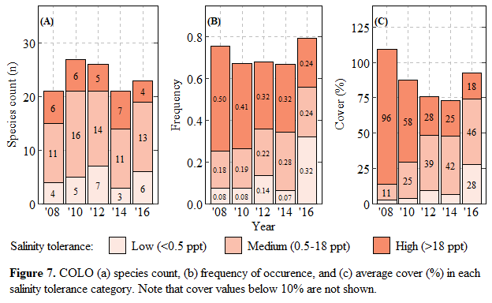

##### *3.5.3* Salinity Tolerance: FIIS

At FIIS, the count of species in all salinity tolerance categories varied between years but ultimately remained stable between 2009 to 2017 (Figure 8a). Similarly, the frequency of occurrence of species with mediuam and high salinity tolerance remained stable, whereas the frequency of species with low salinity tolerance decreased slightly (Figure 8b). The average cover of species with low and high salinity tolerance declined between 2009 to 2017, whereas the average cover of species with medium salinity tolerance remained stable during this time (Figure 8c).

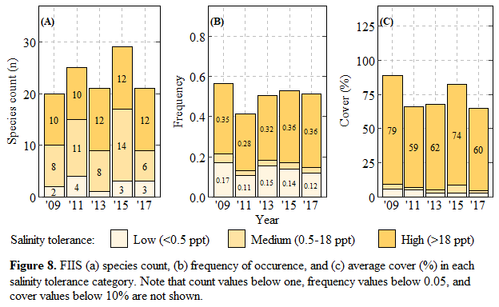

##### *3.5.4* Salinity Tolerance: GATE

At GATE, the count of species in all salinity tolerance categories remained stable between 2010 to 2018 (Figure 9a). The frequency of occurrence of species with medium salinity tolerance increased slightly over the study period, whereas the frequency of occurrence of species with either low or high salinity tolerance remained stable. (Figure 9b). However, the average cover of species with either low or high salinity tolerance decreased over the study period, whereas the average cover of species with medium salinity tolerance remained stable (Figure 9c). Note that differences between the year 2014 and other years are most likely related to the fact that only 1 site (out of 3) was sampled in 2014.

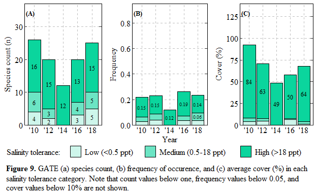

##### *3.5.5* Salinity Tolerance: GEWA

At GEWA, the count of species with low and medium salinity tolerance decreased between 2008 to 2012, whereas the count of species with high salinity tolerance remained stable (Figure 10a). Conversely, the frequency of occurrence of species with low salinity tolerance increased, whereas the frequency of occurrence of species with medium and high salinity tolerance remained stable (Figure 10b). Interestingly, the average cover of species with low salinity tolerance remained stable during the study period, although the average cover of species with medium and high salinity tolerance decreased between 2008 to 2012 (Figure 10c).

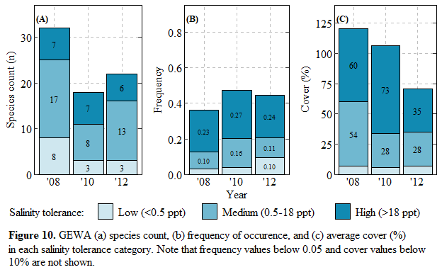

##### *3.5.6* Salinity Tolerance: SAHI

At SAHI, no species with low salinity tolerance were found throughout the entire study period. The count of species with medium and high salinity tolerance remained stable (Figure 11a). Similarly, the frequency of occurrence and cover of species with both medium and high salinity tolerance remained stable (Figure 11b and c).

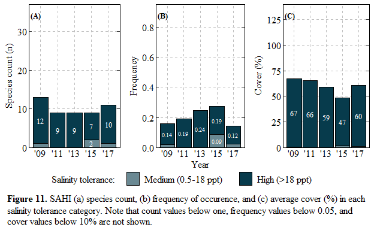

##### **3.6** Community Classes

##### *3.6.1* Community Classes: ASIS

The species present at ASIS were classified as either salt marsh open ditch, salt marsh plugged ditch, salt marsh pool/panne, salt marsh shoreline, or tidal lagoon. The count of species in the salt marsh open ditch class decreased between 2008 to 2018 (Figure 12a). Species classified as salt marsh shoreline were not found in 2012 and 2014 (Figure 12a). The count of species in the remaining three classes remained stable (Figure 12a). The frequency of occurrence of species in the salt marsh pool/panne class decreased, whereas the frequency of occurrence of species in the remaining four classes remained stable (Figure 12b). The average cover of species in the salt marsh open ditch, salt marsh shoreline, and salt marsh pool/panne classes decreased whereas the average cover of species in the salt marsh plugged ditch and tidal lagoon classes remained stable (Figure 12c).

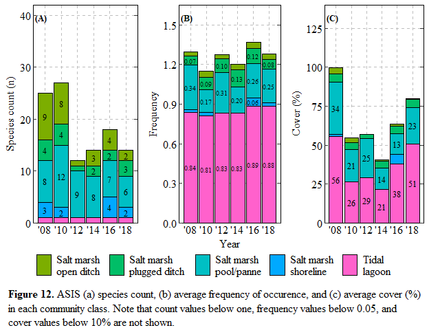

##### *3.6.2* Community Classes: COLO

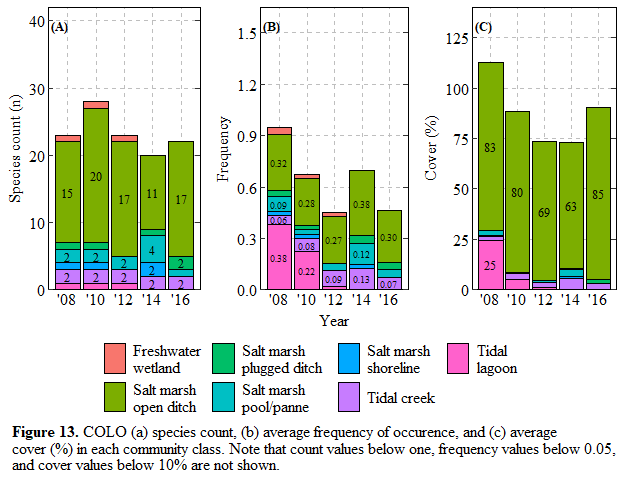

##### *3.6.3* Community Classes: FIIS

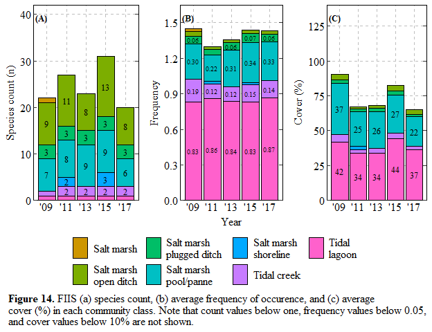

##### *3.6.4* Community Classes: GATE

The species present at GATE were classified as either salt marsh, salt marsh open ditch, salt marsh plugged ditch, salt marsh pool/panne, salt marsh shoreline, tidal creek, or tidal lagoon. The count of species in the salt marsh, salt marsh plugged ditch, salt marsh pool/panne, tidal creek, and tidal lagoon classes remained stable between 2010 to 2018. The count of species in the salt marsh open ditch class decreased over time, and no species in the salt marsh shoreline class were found in 2012 or 2014 (Figure 15a). The frequency of occurrence of species classified as salt marsh plugged ditch decreased between 2010 to 2018 whereas the frequency of species in the remaining six classes remained stable (Figure 15b). The cover of species in the salt marsh, salt marsh open ditch, salt marsh plugged ditch, and salt marsh pool/panne classes decreased over the sampling period, whereas the cover of species in the salt marsh shoreline, tidal creek, and tidal lagoon classes remained stable over time (Figure 15c). Note that differences between the year 2014 and other years are most likely related to the fact that only 1 site (out of 3) was sampled in 2014.

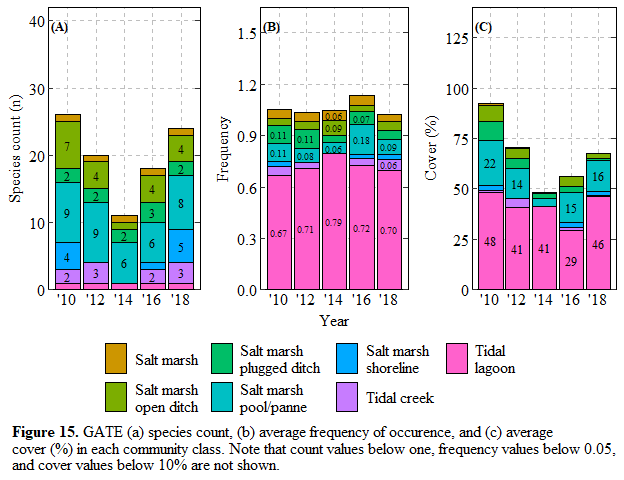

##### *3.6.5* Community Classes: GEWA

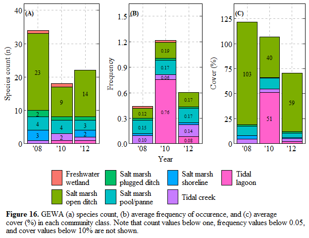

##### *3.6.6* Community Classes: SAHI

The species present at SAHI were classified as either salt marsh open ditch, salt marsh plugged ditch, salt marsh pool/panne, tidal creek, or tidal lagoon. Only a single species classified as tidal creek - *Bassia hyssopifolia* - was found in 2009 (Figure 17a). Similarly, no species in the salt marsh open ditch class were found in 2013 (Figure 17a). The count of species in the salt marsh plugged ditch, salt marsh pool/panne, and tidal lagoon remained stable over the study period(Figure 17a). With the exception of the tidal creek class, the frequency of occurrence of all other classes remained stable between 2009 to 2017 (Figure 17b). Only the cover of species in the salt marsh open ditch and tidal lagoon (i.e., *Spartina alterniflora*) classes increased over the sampling period, whereas cover of the other classes remained stable over time (Figure 17c).

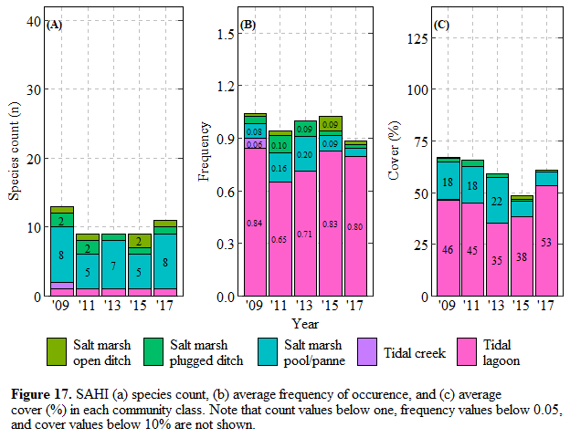

##### **3.7** Community Composition

##### *3.7.1* Community Composition: ASIS

At ASIS, there was a significant difference in community composition between years (*R*2 = 0.06, *p* < 0.001). An examination of the pairwise comparisons between years at ASIS found significant differences between all year pairs. (Figure 18). Only the species with the top five greatest changes in cover that contributed to the differences between these 15 year-pairs at ASIS are shown in Figure 18. Additional species with significant differences in cover between at least one year pair at ASIS include *Atriplex patula*, *Elymus virginicus*, *Eragrostis spp.*, *Iva frutescens*, *Juncus gerardii*, *Limonium carolinianum*, *Schoenoplectus pungens var. pungens*, and *Smilax rotundifolia*.

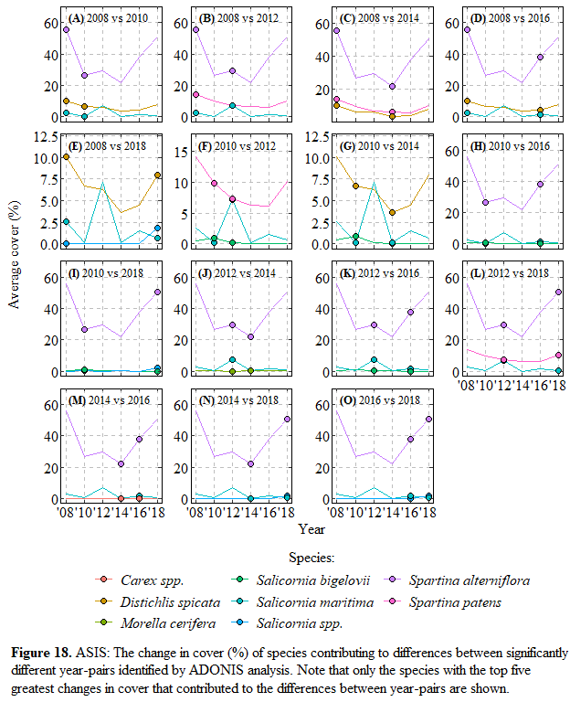

##### *3.7.2* Community Composition: COLO

At COLO, there was a significant difference in community composition between years (*R*2 = 0.21, *p* < 0.001). An examination of the pairwise comparisons between years at COLO found significant differences between all year pairs (Figure 19). Only the species with the top five greatest changes in cover that contributed to the differences between these ten year-pairs at COLO are shown in Figure 19. Additional species with significant differences in cover between at least one year pair at COLO include *Amaranthus cannabinus*, *Carex hyalinolepsis*, *Carex lurida*, *Eleocharis parvula*, *Juncus effusus*, *Juncus gerardii*, *Juncus roemarianus*, *Juncus tenuis*, *Leersia oryzoides*, *Lythrum lineare*, *Mikania scandens*, *Phragmites australis*, *Pluchea odorata*, *Polygonum punctatum*, *Pontedaria cordata*, *Schoenoplectus americanus*, *Schoenoplectus pungens var. pungens*, *Schoenoplectus tabernaemontani*, *Typha spp.*, *Typha angustifolia*, and *Zizaniopsis miliacea*.

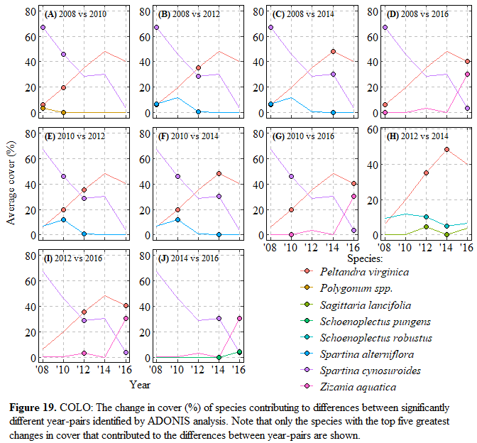

##### *3.7.3* Community Composition: FIIS

At FIIS, there was a significant difference in community composition between years (*R*2 = 0.03, *p* < 0.001). An examination of the pairwise comparisons between years at FIIS found significant differences between all year pairs (Figure 20). Only the species with the top four greatest changes in cover that contributed to the differences between these ten year-pairs at FIIS are shown in Figure 20. Additional species with significant differences in cover between at least one year pair at FIIS include *Atriplex patula*, *Hibiscus spp.*, *Hibiscus moscheutos*, *Kosteletzkya virginica*, *Limonium carolinianum*, *Salicornia bigelovii*, *Schoenoplectus pungens*, *Schoenoplectus pungens var. pungens*, *Schoenoplectus robustus*, *Suaeda maritima*, *Symphyotrichum tenuifolium*, and *Typha angustifolia*.

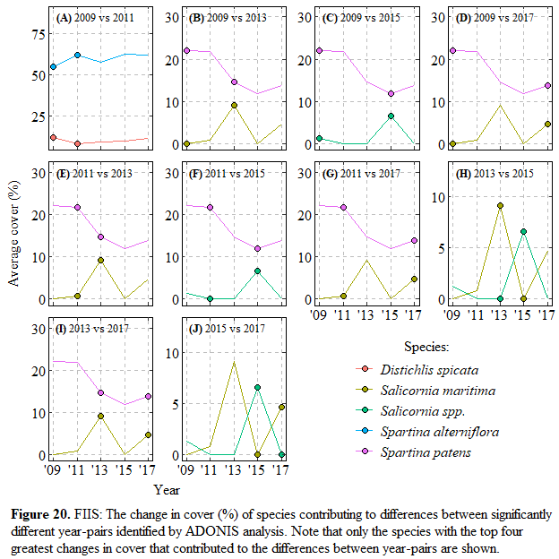

##### *3.7.4* Community Composition: GATE

At GATE, there was a significant differnce in community composition between years (*R*2 = 0.03, *p* < 0.001). An examination of the pairwise comparisons between years at GATE found significant differences between 2010 vs. 2014, 2010 vs. 2016, 2014 vs. 2016, 2014 vs. 2018, and 2016 vs. 2018 (Figure 21). Only the species with the top five greatest changes in cover that contributed to the differences between these five year-pairs at GATE are shown in Figure 21. Additional species with significant differences in cover between at least one year pair at GATE include *Iva frutescens*, *Salicornia spp.*, and *Spartina alterniflora*.

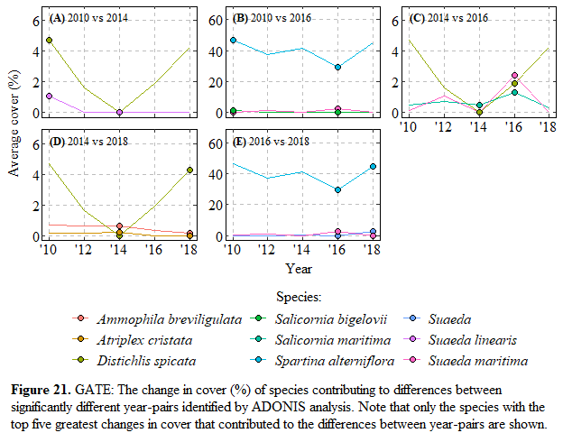

##### *3.7.5* Community Composition: GEWA

At GEWA, there was a significant difference in community composition between years (*R*2 = 0.19, *p* < 0.001). An examination of the pairwise comparisons between years at GEWA found significant differences between all year pairs (Figure 22). The species with significant differences in cover that contributed to the differences between these year-pairs at GEWA are shown in Figure 22.

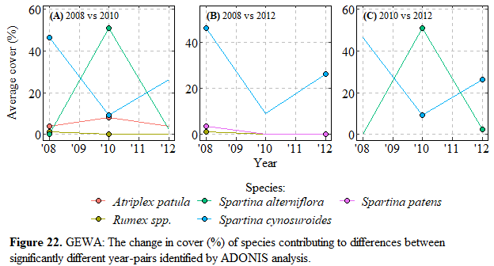

##### *3.7.6* Community Composition: SAHI

At SAHI, there was a significant difference in community composition between years (*R*2 = 0.04, *p* < 0.01). An examination of the pairwise comparisons between years at SAHI found significant differences between 2009 vs. 2011, 2009 vs. 2013, 2011 vs. 2013, 2011 vs. 2015, 2011 vs. 2017, 2013 vs. 2015, 2013 vs. 2017, and 2015 vs. 2017 (Figure 23). Only the species with the top five greatest changes in cover that contributed to the differences between these eight year-pairs at SAHI are shown in Figure 23. Additional species with significant differences in cover between at least one year pair at SAHI include *Atriplex cristata*, *Iva frutescens*, and *Salicornia maritima*.

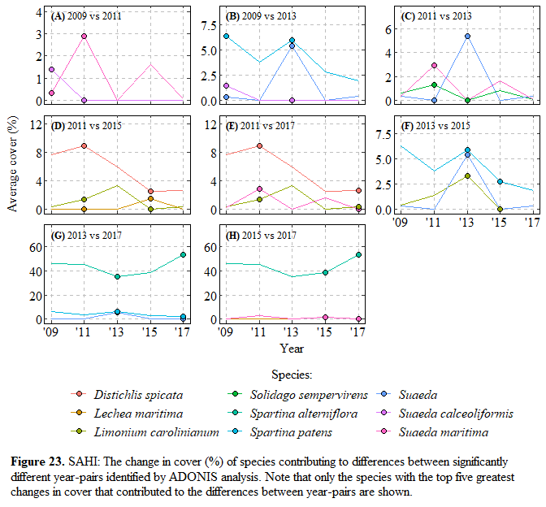

#### **4. Discussion**

##### **4.2** Status of the NCBN Salt Marsh Vegetation Monitoring Protocol

The National Park Service Inventory and Monitoring (I&M) Program’s Northeast Coastal and Barrier Network (NCBN) has identified salt marsh condition, in addition to several associated vital signs, as a high priority for long-term monitoring. The first iteration of the salt marsh vegetation monitoring protocol was originally developed by the USGS and University of Rhode Island for the purpose of comparing the vegetation community in hydrologically altered marshes to more pristine ‘control’ marshes in order to understand the potential effects of hydrologic restoration on salt marsh habitats within Cape Cod National Seashore (Roman et al., 2001). This protocol was then adapted to measure change in the species composition and abundance of the salt marsh plant community at the other six coastal parks monitored by NCBN in response to a multitude of stressors such as hydrologic alteration, storms, visitor use, nutrient loading, watershed development, sea-level rise and climate change, among others (Rocks and Stevens 2018). The salt marsh vegetation monitoring protocol was successfully implemented across seven NCBN parks over a period of 10 years from 2008 to 2018, but was placed on hold in 2018 due to staffing and budget shortages. During the years that this protocol was in use, it was by far the most labor- and time-intensive vital sign monitored by NCBN. For instance, assuming a four person crew (two full-time biologists and two interns) was used for each sampling event, a conservative estimate of 7,072 total man-hours were dedicated to field data collection alone during this time (i.e., 221 sampling events *x* 8 hours per day *x* 4 crew members). Further more, this estimate does not include the additional time needed for traveling to and from the NCBN main office (Kingston, Rhode Island) to each park, logistical considerations (e.g., time for budget and travel planning, equipment preparation, clean-up, etc.), or data management and annual reporting tasks, among others. For a more specific example, it took a total of 13 full days to complete field sampling at just 1 park - ASIS - in 2018. Similarly, this protocol was also one of the more budget intensive monitoring programs conducted by NCBN. In 2018, Rocks and Stevens (2018) estimated that the annual operational cost associated with the NCBN salt marsh vegetation monitoring was $50,000 per year - a figure that would likely be much higher today.

The data summaries that were suggested for annual reporting in the protocol implementation plan (Rocks and Stevens 2018) include species composition (species lists), percent cover for all cover types by site, and presence of any federal, state-listed and/or non-native species. Additionally, the protocol implementation plan also recommends that trend analysis be conducted on a 3-5 year basis and suggests the use of non-parametric multivariate community analysis methods such as analysis of similarities (ANOSIM) and similarity of percentages analysis (SIMPER) in order to understand change over time. The suggestion to include species lists for annual reporting are necessary in order to have a record of the full suite of species at each park and the compilation of these lists is relatively straightforward and easy to interpret. However, the recommended trend analysis (ANOSIM and SIMPER) do not actually calculate trends and only indicate where differences between plant communities have occurred in the previous sample years. For example, the ADONIS model and subsequent pairwise comparisons (which is analogous to ANOSIM and SIMPER) for FIIS suggest that there is a significant difference in community composition between 2015 vs. 2017, but does not provide any information about overall long-term trends in community composition. As such, these methods of analysis have limited value for understanding the broader ‘big-picture’ changes in these salt marsh plant communities and also do not provide a means for anticipating (i.e., predicting) future changes and developing management actions that may be needed to either counteract or facilitate these changes.

#### **5. Literature Cited**

Benjamini, Y., and Y. Hochberg. 1995. Controlling the false discovery rate: a practical and powerful approach to multiple testing. Journal of the Royal Statistical Society Series B 57:289-300. doi.org/10.1111/j/2517-6161.1995.tb02031.x.

Lichvar, R.W., D.L. Banks, W.N. Kirchner, and N.C. Melvin. 2016. The National Wetland Plant List: 2016 wetland ratings. Phytoneuron 2016-30: 1-17. https://wetland-plants.sec.usace.army.mil/.

Mason Harris, J., W.P. Broussard III, and J.A. Nelson. 2024. Evaluating coastal wetland restoration using drones and high-resolution imagery. Estuaries and Coasts 47:1359-1375. doi.org/10.1007/s12237-024-01376-1.

Nicosia, E.L., and P.S. Pooler. 2012a. Monitoring salt marsh vegetation and nekton at Fire Island National Seashore: 2011 summary report. Natural Resource Data Series NPS/NCBN/NRDS—2012/397. National Park Service, Fort Collins, Colorado.

Nicosia, E.L., and P.S. Pooler. 2012b. Monitoring salt marsh vegetation and nekton at William Floyd Estate, Fire Island National Seashore: 2011 summary report. Natural Resource Data Series NPS/NCBN/NRDS—2012/399. National Park Service, Fort Collins, Colorado.

Nicosia, E.L., and P.S. Pooler. 2012c. Monitoring salt marsh vegetation and nekton at Sagamore Hill National Historic Site: 2011 summary report. Natural Resource Data Series NPS/NCBN/NRDS—2012/398. National Park Service, Fort Collins, Colorado.

Nicosia, E.L. 2013a. Monitoring salt marsh vegetation and nekton at Assateague Island National Seashore: 2012 summary report. Natural Resource Data Series NPS/NCBN/NRDS—2013/655. National Park Service, Fort Collins, Colorado.

Nicosia, E.L. 2013b. Monitoring salt marsh vegetation at Colonial National Historical Park: 2012 summary report. Natural Resource Data Series NPS/NCBN/NRDS—2013/444. National Park Service, Fort Collins, Colorado.

Nicosia, E.L. 2013c. Monitoring salt marsh vegetation and nekton at Gateway National Recreation Area’s Sandy Hook Unit: 2012 summary report. Natural Resource Data Series NPS/NCBN/NRDS—2013/458. National Park Service, Fort Collins, Colorado.

Nicosia, E.L. 2013d. Monitoring salt marsh vegetation at George Washington Birthplace National Monument: 2012 summary report. Natural Resource Data Series NPS/NCBN/NRDS—2013/442. National Park Service, Fort Collins, Colorado.

Nicosia, E.L. 2015a. Monitoring salt marsh vegetation at Colonial National Historical Park: 2014 summary report. Natural Resource Data Series NPS/NCBN/NRDS—2015/791. National Park Service, Fort Collins, Colorado.

Nicosia, E.L. 2015b. Monitoring salt marsh vegetation and nekton at Fire Island National Seashore and the William Floyd Estate: 2015 summary report. Natural Resource Data Series NPS/NCBN/NRDS—2015/995. National Park Service, Fort Collins, Colorado.

Nicosia, E.L. 2015c. Monitoring salt marsh vegetation at Gateway National Recreation Area’s Sandy Hook Unit: 2014 summary report. Natural Resource Data Series NPS/NCBN/NRDS—2015/793. National Park Service, Fort Collins, Colorado.

Nicosia, E.L. 2015d. Monitoring salt marsh vegetation and nekton at Sagamore Hill National Historic Site: 2015 summary report. Natural Resource Data Series NPS/NCBN/NRDS—2015/996. National Park Service, Fort Collins, Colorado.

Patenaude, E.L., and P.S. Pooler. 2010a. Salt marsh vegetation and nekton community monitoring at Assateague Island National Seashore: 2008 summary report. Natural Resource Data Series NPS/NCBN/NRDS—2010/065. National Park Service, Fort Collins, Colorado.

Patenaude, E.L., and P.S. Pooler. 2010b. Salt marsh vegetation monitoring at Colonial National Historical Park: 2008 summary report. Natural Resource Data Series NPS/NCBN/NRDS—2010/066. National Park Service, Fort Collins, Colorado.

Patenaude, E.L., and P.S. Pooler. 2010c. Monitoring salt marsh vegetation at Colonial National Historical Park: 2010 summary report. Natural Resource Data Series NPS/NCBN/NRDS—2010/120. National Park Service, Fort Collins, Colorado.

Patenaude, E.L., and P.S. Pooler. 2010d. Salt marsh vegetation and nekton community monitoring at William Floyd Estate, Fire Island National Seashore. Natural Resource Technical Report NPS/NCBN/NRDS—2010/070. National Park Service, Fort Collins, Colorado.

Patenaude, E.L., and P.S. Pooler. 2010e. Salt marsh vegetation and nekton community monitoring at Fire Island National Seashore: 2009 summary report. Natural Resource Data Series NPS/NCBN/NRDS—2010/068. National Park Service, Fort Collins, Colorado.

Patenaude, E.L., and P.S. Pooler. 2010f. Salt marsh vegetation and nekton community monitoring at William Floyd Estate, Fire Island National Seashore: 2009 summary report. Natural Resource Data Series NPS/NCBN/NRDS—2010/070. National Park Service, Fort Collins, Colorado.

Patenaude, E.L., and P.S. Pooler. 2010g. Salt marsh vegetation and nekton community monitoring at George Washington Birthplace National Monument: 2008 summary report. Natural Resource Data Series NPS/NCBN/NRDS—2010/069. National Park Service, Fort Collins, Colorado.

Patenaude, E.L., and P.S. Pooler. 2010h. Salt marsh vegetation and nekton community monitoring at Sagamore Hill National Historical Site: 2009 summary report. Natural Resource Data Series NPS/NCBN/NRDS—2010/067. National Park Service, Fort Collins, Colorado.

Patenaude, E.L., and P.S. Pooler. 2011a. Monitoring salt marsh vegetation and nekton at Assateague Island National Seashore: 2010 summary report. Natural Resource Data Series NPS/NCBN/NRDS—2011/312. National Park Service, Fort Collins, Colorado.

Patenaude, E.L., and P.S. Pooler. 2011b. Monitoring salt marsh vegetation and nekton at Gateway National Recreation Area’s Sandy Hook Unit: 2010 summary report. Natural Resource Data Series NPS/NCBN/NRDS—2011/132. National Park Service, Fort Collins, Colorado.

Patenaude, E.L., and P.S. Pooler. 2011c. Salt marsh vegetation and nekton community monitoring at George Washington Birthplace National Monument: 2010 summary report. Natural Resource Data Series NPS/NCBN/NRDS—2011/133. National Park Service, Fort Collins, Colorado.

Rocks, E.N., and S.M. Stevens. 2018. Northeast Coastal and Barrier Network salt marsh vegetation monitoring protocol implementation plan: Version 1.0. Natural Resource Report NPS/NCBN/NRR—2018/1790. National Park Service, Fort Collins, Colorado.

Roman, C.T., M.J. James-Pirri, and J.F. Heltshe. 2001. Monitoring Salt Marsh Vegetation: A Protocol for the Long-term Coastal Ecosystem Monitoring Program at Cape Cod National Seashore. Coordinated by the USGS Patuxent Wildlife Research Center, Coastal Research Field Station at the University of Rhode Island, Narragansett, RI 02882. Available at https://irma.nps.gov/DataStore/Reference/Profile/563500.

Smith, S.M. 2015. Salt marsh vegetation monitoring report, Cape Cod National Seashore: A summary of monitoring data from 2003, 2008, and 2013. Natural Resource Report NPS/CACO/NRR-2015/920. National Park Service, Fort Collins, Colorado.

State of New York. 2022. [New York Laws, Environmental Conservation § 9-170](https://law.justia.com/codes/new-york/2022/env/article-9/title-17/9-1709/). New York Department of State. 2021. 6 New York Codes, Rules and Regulations Part 575: Prohibited and Regulated Invasive Species.

U.S. Army Corps of Engineers. 2009. Regional supplement to the Corps of Engineers Wetland Delineation Manual: Northcentral and Northeast Region. U.S. Army Corps of Engineers, Engineer Research and Development Center, Environmental Laboratory ERDC/EL TR-09-19.

Warton, D.I., Wright, T.W., Wang, Y. 2012. Distance-based multivariate analyses confound location and dispersion effects. Methods in Ecology and Evolution, 3, 89–101.

#### **6. Appendices**

| Appendix 1. Data sources for rare and invasive species lists for each state. State | Appendix 1. Data sources for rare and invasive species lists for each state. Rare species list source | Appendix 1. Data sources for rare and invasive species lists for each state. Invasive species list source |
| --- | --- | --- |
| MA | https://www.mass.gov/info-details/list-of- endangered-threatened-and-special-concern- species | https://massnrc.org/mipag/species reviewed_category.htm |
| NY | https://www.nynhp.org/documents/5/rare- plant-status-lists-2023.pdf | https://govt.westlaw.com/nycrr/Browse/Home/ NewYork/NewYorkCodesRulesandRegulations? guid=Ie8d3e7b0339611e4baa20000845b8d3e& originationContext=documenttoc&transitionType= Default&contextData=(sc.Defa… |
| NJ | https://www.nj.gov/dep/parksandforests/ natural/docs/njplantlist.pdf | https://dep.nj.gov/invasive-species/plants/ |
| MD | https://dnr.maryland.gov/wildlife/documents/ rte_plant_list.pdf | https://mda.maryland.gov/plants-pests/ Documents/Invasive-Plant-List-March-2020.pdf |
| VA | https://www.dcr.virginia.gov/natural- heritage/document/plantlist-current.pdf | https://www.dcr.virginia.gov/natural-heritage/ invsppdflist |

| Appendix 2. The salinity tolerance and community classification of each species. Salinity tolerance categories are from the USDA Plants database. Low = < 0.5 ppt, Medium = 0.5 to 18 ppt, High = > 18 p… Species | Appendix 2. The salinity tolerance and community classification of each species. Salinity tolerance categories are from the USDA Plants database. Low = < 0.5 ppt, Medium = 0.5 to 18 ppt, High = > 18 p… Salinity Tolerance | Appendix 2. The salinity tolerance and community classification of each species. Salinity tolerance categories are from the USDA Plants database. Low = < 0.5 ppt, Medium = 0.5 to 18 ppt, High = > 18 p… Community Class |
| --- | --- | --- |
| Acalypha rhomboidea | Unlisted | Unlisted |
| Acer rubrum | Medium | Salt marsh shoreline |
| Ageratina altissima | Unlisted | Unlisted |
| Alnus serrulata | Low | Salt marsh open ditch |
| Amaranthus cannabinus | Medium | Salt marsh open ditch |
| Amelanchier canadensis | Low | Salt marsh shoreline |
| Ammophila breviligulata | High | Salt marsh open ditch |
| Andropogon virginicus | Medium | Salt marsh open ditch |
| Apios americana | Unlisted | Unlisted |
| Artemisia vulgaris | Unlisted | Unlisted |
| Aster spp. | Unlisted | Unlisted |
| Atriplex cristata | High | Salt marsh pool/panne |
| Atriplex patula | High | Salt marsh pool/panne |
| Baccharis halimifolia | Medium | Salt marsh plugged ditch |
| Bassia hirsuta | High | Unlisted |
| Bassia hyssopifolia | High | Tidal creek |
| Bassia spp. | Unlisted | Unlisted |
| Bidens bipinnata | Unlisted | Unlisted |
| Boehmeria cylindrica | Low | Salt marsh open ditch |
| Brasenia schreberi | Medium | Freshwater wetland |
| Bromus spp. | Unlisted | Unlisted |
| Cakile edentula | High | Salt marsh |
| Calystegia sepium | Medium | Salt marsh open ditch |
| Carex hyalinolepis | Medium | Salt marsh open ditch |
| Carex kobomugi | Medium | Unlisted |
| Carex lurida | Low | Salt marsh open ditch |
| Carex spp. | Unlisted | Salt marsh open ditch |
| Celtis occidentalis | Low | Salt marsh shoreline |
| Cenchrus longispinus | Medium | Salt marsh shoreline |
| Cenchrus tribuloides | Unlisted | Unlisted |

[output cut: 127 more lines]

| Appendix 2. Salt marsh plant cover species with the top five highest average cover, frequency, and importance value in each park unit. Importance values were calculated as the mean of the average cove… Park Unit | Appendix 2. Salt marsh plant cover species with the top five highest average cover, frequency, and importance value in each park unit. Importance values were calculated as the mean of the average cove… Species | Appendix 2. Salt marsh plant cover species with the top five highest average cover, frequency, and importance value in each park unit. Importance values were calculated as the mean of the average cove… Cover (%) | Appendix 2. Salt marsh plant cover species with the top five highest average cover, frequency, and importance value in each park unit. Importance values were calculated as the mean of the average cove… Species | Appendix 2. Salt marsh plant cover species with the top five highest average cover, frequency, and importance value in each park unit. Importance values were calculated as the mean of the average cove… Frequency | Appendix 2. Salt marsh plant cover species with the top five highest average cover, frequency, and importance value in each park unit. Importance values were calculated as the mean of the average cove… Species | Appendix 2. Salt marsh plant cover species with the top five highest average cover, frequency, and importance value in each park unit. Importance values were calculated as the mean of the average cove… Importance |
| --- | --- | --- | --- | --- | --- | --- |
| ASIS | Spartina alterniflora H5 | 36.8 | Spartina alterniflora H5 | 0.85 | Spartina alterniflora H5 | 6.08 |
|  | Spartina patens H3 | 9.7 | Distichlis spicata H3 | 0.40 | Distichlis spicata H3 | 2.34 |
|  | Distichlis spicata H3 | 6.7 | Salicornia maritima H3 | 0.30 | Spartina patens H3 | 1.81 |
|  | Iva frutescens H7 | 3.6 | Spartina patens H3 | 0.26 | Salicornia maritima H3 | 1.61 |
|  | Pinus taeda L8 | 2.1 | Iva frutescens H7 | 0.09 | Iva frutescens H7 | 0.63 |
| COLO | Spartina cynosuroides H2 | 30.8 | Peltandra virginica M2 | 0.68 | Spartina cynosuroides H2 | 4.55 |
|  | Peltandra virginica M2 | 21.1 | Spartina cynosuroides H2 | 0.60 | Peltandra virginica M2 | 4.48 |
|  | Spartina alterniflora H5 | 10.2 | Schoenoplectus robustus H2 | 0.37 | Schoenoplectus robustus H2 | 2.16 |
|  | Zizania aquatica L2 | 6.8 | Zizania aquatica L2 | 0.21 | Zizania aquatica L2 | 1.39 |
|  | Schoenoplectus robustus H2 | 6.3 | Schoenoplectus pungens var. pungens M2 | 0.17 | Schoenoplectus pungens var. pungens M2 | 0.98 |
| FIIS | Spartina alterniflora H5 | 38.1 | Spartina alterniflora H5 | 0.84 | Spartina alterniflora H5 | 6.13 |
|  | Spartina patens H3 | 14.1 | Spartina patens H3 | 0.42 | Spartina patens H3 | 2.82 |
|  | Distichlis spicata H3 | 7.6 | Distichlis spicata H3 | 0.39 | Distichlis spicata H3 | 2.35 |
|  | Phragmites australis IL4 | 3.2 | Salicornia maritima H3 | 0.28 | Salicornia maritima H3 | 1.54 |
|  | Salicornia maritima H3 | 2.6 | Salicornia spp. H3 | 0.21 | Salicornia spp. H3 | 1.16 |
| GATE | Spartina alterniflora H5 | 41.2 | Spartina alterniflora H5 | 0.71 | Spartina alterniflora H5 | 5.60 |
|  | Spartina patens H3 | 6.6 | Spartina patens H3 | 0.19 | Spartina patens H3 | 1.26 |
|  | Distichlis spicata H3 | 3.8 | Distichlis spicata H3 | 0.09 | Distichlis spicata H3 | 0.65 |
|  | Iva frutescens H7 | 3.6 | Iva frutescens H7 | 0.08 | Iva frutescens H7 | 0.60 |
|  | Phragmites australis IL4 | 2.9 | Salicornia maritima H3 | 0.08 | Salicornia maritima H3 | 0.44 |
| GEWA | Spartina cynosuroides H2 | 27.3 | Amaranthus cannabinus M2 | 0.68 | Amaranthus cannabinus M2 | 4.19 |
|  | Spartina alterniflora H5 | 26.7 | Spartina cynosuroides H2 | 0.54 | Spartina cynosuroides H2 | 4.07 |
|  | Amaranthus cannabinus M2 | 16.3 | Atriplex patula H3 | 0.46 | Spartina alterniflora H5 | 2.73 |
|  | Kosteletzkya virginica M2 | 10.0 | Kosteletzkya virginica M2 | 0.34 | Atriplex patula H3 | 2.55 |
|  | Atriplex patula H3 | 5.3 | Spartina alterniflora H5 | 0.28 | Kosteletzkya virginica M2 | 2.20 |
| SAHI | Spartina alterniflora H5 | 43.6 | Spartina alterniflora H5 | 0.76 | Spartina alterniflora H5 | 6.00 |
|  | Distichlis spicata H3 | 5.6 | Distichlis spicata H3 | 0.16 | Distichlis spicata H3 | 1.10 |
|  | Spartina patens H3 | 4.2 | Spartina patens H3 | 0.13 | Spartina patens H3 | 0.87 |
|  | Suaeda spp. H3 | 2.0 | Limonium carolinianum H3 | 0.10 | Suaeda spp. H3 | 0.56 |
|  | Iva frutescens H7 | 1.6 | Atriplex cristata H3 | 0.10 | Limonium carolinianum H3 | 0.55 |

| Appendix 3A. Salt marsh plant species list for Assateague Island National Seashore. Species labeled with .spp could not be identified beyond the genus level. Common names and symbols are derived from … Species | Appendix 3A. Salt marsh plant species list for Assateague Island National Seashore. Species labeled with .spp could not be identified beyond the genus level. Common names and symbols are derived from … Common Name | Appendix 3A. Salt marsh plant species list for Assateague Island National Seashore. Species labeled with .spp could not be identified beyond the genus level. Common names and symbols are derived from … Symbol |
| --- | --- | --- |
| Andropogon virginicus | broomsedge bluestem | ANVI2 |
| Aster spp. |  |  |
| Atriplex patula | spear saltbush | ATPA4 |
| Baccharis halimifolia | eastern baccharis | BAHA |
| Carex spp. |  |  |
| Dichanthelium acuminatum var. fasciculatum | western panicgrass | DIACF |
| Distichlis spicata | saltgrass | DISP |
| Eleocharis spp. |  |  |
| Elymus virginicus | Virginia wildrye | ELVI3 |
| Eragrostis spp. |  |  |
| Festuca rubra | red fescue | FERU2 |
| Ilex opaca | American holly | ILOP |
| Iva frutescens | Jesuit's bark | IVFR |
| Juncus effusus | common rush | JUEF |
| Juncus gerardii | saltmeadow rush | JUGE |
| Juncus roemerianus | needlegrass rush | JURO |
| Limonium carolinianum | lavender thrift | LICA17 |
| Lythrum lineare | wand lythrum | LYLI2 |
| Mitchella repens | partridgeberry | MIRE |
| Morella cerifera | wax myrtle | MOCE2 |
| Morella pensylvanica | northern bayberry | MOPE6 |
| Panicum virgatum | switchgrass | PAVI2 |
| Parthenocissus quinquefolia | Virginia creeper | PAQU2 |
| Phytolacca americana | American pokeweed | PHAM4 |
| Pinus rigida | pitch pine | PIRI |
| Pinus taeda | loblolly pine | PITA |
| Salicornia bigelovii | dwarf saltwort | SABI |
| Salicornia maritima | slender grasswort | SAMA11 |
| Salicornia spp. |  |  |
| Samolus valerandi ssp. parviflorus | seaside brookweed | SAVAP |
| Schoenoplectus americanus | chairmaker's bulrush | SCAM6 |
| Schoenoplectus pungens | common threesquare | SCPU10 |
| Schoenoplectus pungens var. pungens | common threesquare | SCPUP5 |
| Schoenoplectus robustus | sturdy bulrush | SCRO5 |
| Smilax rotundifolia | roundleaf greenbrier | SMRO |
| Solidago sempervirens | seaside goldenrod | SOSE |
| Spartina alterniflora | smooth cordgrass | SPAL |
| Spartina patens | saltmeadow cordgrass | SPPA |
| Suaeda maritima | herbaceous seepweed | SUMA |
| Toxicodendron radicans | eastern poison ivy | TORA2 |
| Vitis rotundifolia | muscadine | VIRO3 |

| Appendix 3B. Salt marsh plant species list for Colonial National Historical Park. Species labeled with .spp could not be identified beyond the genus level. Common names and symbols are derived from th… Species | Appendix 3B. Salt marsh plant species list for Colonial National Historical Park. Species labeled with .spp could not be identified beyond the genus level. Common names and symbols are derived from th… Common Name | Appendix 3B. Salt marsh plant species list for Colonial National Historical Park. Species labeled with .spp could not be identified beyond the genus level. Common names and symbols are derived from th… Symbol |
| --- | --- | --- |
| Acer rubrum | red maple | ACRU |
| Amaranthus cannabinus | tidalmarsh amaranth | AMCA2 |
| Apios americana | groundnut | APAM |
| Baccharis halimifolia | eastern baccharis | BAHA |
| Brasenia schreberi | watershield | BRSC |
| Carex hyalinolepis | shoreline sedge | CAHY3 |
| Carex lurida | shallow sedge | CALU5 |
| Carex spp. |  |  |
| Distichlis spicata | saltgrass | DISP |
| Eleocharis parvula | dwarf spikerush | ELPA5 |
| Hibiscus moscheutos | crimsoneyed rosemallow | HIMO |
| Hydrocotyle spp. |  |  |
| Hydrocotyle verticillata | whorled marshpennywort | HYVE2 |
| Iva frutescens | Jesuit's bark | IVFR |
| Juncus effusus | common rush | JUEF |
| Juncus gerardii | saltmeadow rush | JUGE |
| Juncus roemerianus | needlegrass rush | JURO |
| Juncus spp. |  |  |
| Juncus tenuis | poverty rush | JUTE |
| Juniperus virginiana | eastern redcedar | JUVI |
| Leersia oryzoides | rice cutgrass | LEOR |
| Leersia spp. |  |  |
| Lilaeopsis chinensis | eastern grasswort | LICH |
| Lonicera spp. |  |  |
| Lycopus spp. |  |  |
| Lythrum lineare | wand lythrum | LYLI2 |
| Mikania scandens | climbing hempvine | MISC |
| Morella cerifera | wax myrtle | MOCE2 |
| Najas minor | brittle waternymph | NAMI |
| Osmunda regalis | royal fern | OSRE |
| Peltandra virginica | green arrow arum | PEVI |
| Persea borbonia | redbay | PEBO |
| Phragmites australis | common reed | PHAU7 |
| Phyla lanceolata | lanceleaf fogfruit | PHLA3 |
| Pinus rigida | pitch pine | PIRI |
| Pluchea odorata | sweetscent | PLOD |
| Polygonum persicaria | spotted ladysthumb | POPE3 |
| Polygonum punctatum | dotted smartweed | POPU5 |
| Polygonum spp. |  |  |
| Pontederia cordata | pickerelweed | POCO14 |
| Ptilimnium capillaceum | herbwilliam | PTCA |
| Rumex verticillatus | swamp dock | RUVE3 |
| Sagittaria lancifolia | bulltongue arrowhead | SALA |
| Sagittaria subulata | awl-leaf arrowhead | SASU |
| Samolus valerandi | seaside brookweed | SAVA3 |
| Samolus valerandi ssp. parviflorus | seaside brookweed | SAVAP |
| Schoenoplectus americanus | chairmaker's bulrush | SCAM6 |
| Schoenoplectus pungens | common threesquare | SCPU10 |
| Schoenoplectus pungens var. pungens | common threesquare | SCPUP5 |
| Schoenoplectus robustus | sturdy bulrush | SCRO5 |
| Schoenoplectus tabernaemontani | softstem bulrush | SCTA2 |
| Spartina alterniflora | smooth cordgrass | SPAL |
| Spartina cynosuroides | big cordgrass | SPCY |
| Spartina patens | saltmeadow cordgrass | SPPA |
| Taxodium distichum | baldcypress | TADI2 |
| Teucrium canadense | Canada germander | TECA3 |
| Thelypteris palustris | eastern marsh fern | THPA |
| Toxicodendron radicans | eastern poison ivy | TORA2 |
| Typha angustifolia | narrowleaf cattail | TYAN |
| Typha spp. |  |  |
| Vitis spp. |  |  |
| Zizania aquatica | annual wildrice | ZIAQ |
| Zizaniopsis miliacea | giant cutgrass | ZIMI |

| Appendix 3C. Salt marsh plant species list for Fire Island National Seashore. Species labeled with .spp could not be identified beyond the genus level. Common names and symbols are derived from the US… Species | Appendix 3C. Salt marsh plant species list for Fire Island National Seashore. Species labeled with .spp could not be identified beyond the genus level. Common names and symbols are derived from the US… Common Name | Appendix 3C. Salt marsh plant species list for Fire Island National Seashore. Species labeled with .spp could not be identified beyond the genus level. Common names and symbols are derived from the US… Symbol |
| --- | --- | --- |
| Ammophila breviligulata | American beachgrass | AMBR |
| Atriplex patula | spear saltbush | ATPA4 |
| Baccharis halimifolia | eastern baccharis | BAHA |
| Bassia hirsuta | hairy smotherweed | BAHI3 |
| Bassia hyssopifolia | fivehorn smotherweed | BAHY |
| Cakile edentula | American searocket | CAED |
| Calystegia sepium | hedge false bindweed | CASE13 |
| Cuscuta spp. |  |  |
| Distichlis spicata | saltgrass | DISP |
| Elaeagnus umbellata | autumn olive | ELUM |
| Eleocharis spp. |  |  |
| Elymus virginicus | Virginia wildrye | ELVI3 |
| Hibiscus moscheutos | crimsoneyed rosemallow | HIMO |
| Hibiscus spp. |  |  |
| Iva frutescens | Jesuit's bark | IVFR |
| Juncus canadensis | Canadian rush | JUCA3 |
| Juncus effusus | common rush | JUEF |
| Juncus gerardii | saltmeadow rush | JUGE |
| Juncus roemerianus | needlegrass rush | JURO |
| Juncus spp. |  |  |
| Kosteletzkya virginica | Virginia saltmarsh mallow | KOVI |
| Lepidium spp. |  |  |
| Limonium carolinianum | lavender thrift | LICA17 |
| Lonicera spp. |  |  |
| Mikania scandens | climbing hempvine | MISC |
| Morella pensylvanica | northern bayberry | MOPE6 |
| Panicum spp. |  |  |
| Parthenocissus quinquefolia | Virginia creeper | PAQU2 |
| Phragmites australis | common reed | PHAU7 |
| Pluchea odorata | sweetscent | PLOD |
| Polygonum perfoliatum | Asiatic tearthumb | POPE10 |
| Polygonum punctatum | dotted smartweed | POPU5 |
| Quercus velutina | black oak | QUVE |
| Rosa spp. |  |  |
| Rubus spp. |  |  |
| Salicornia bigelovii | dwarf saltwort | SABI |
| Salicornia maritima | slender grasswort | SAMA11 |
| Salicornia spp. |  |  |
| Schoenoplectus americanus | chairmaker's bulrush | SCAM6 |
| Schoenoplectus pungens | common threesquare | SCPU10 |
| Schoenoplectus pungens var. pungens | common threesquare | SCPUP5 |
| Schoenoplectus robustus | sturdy bulrush | SCRO5 |
| Scirpus spp. |  |  |
| Setaria parviflora | marsh bristlegrass | SEPA10 |
| Smilax rotundifolia | roundleaf greenbrier | SMRO |
| Solidago rugosa | wrinkleleaf goldenrod | SORU2 |
| Solidago sempervirens | seaside goldenrod | SOSE |
| Spartina alterniflora | smooth cordgrass | SPAL |
| Spartina patens | saltmeadow cordgrass | SPPA |
| Suaeda maritima | herbaceous seepweed | SUMA |
| Suaeda spp. |  |  |
| Symphyotrichum tenuifolium | perennial saltmarsh aster | SYTE6 |
| Teucrium canadense | Canada germander | TECA3 |
| Thelypteris palustris | eastern marsh fern | THPA |
| Toxicodendron radicans | eastern poison ivy | TORA2 |
| Triadenum virginicum | Virginia marsh St. Johnswort | TRVI2 |
| Typha angustifolia | narrowleaf cattail | TYAN |
| Vitis rotundifolia | muscadine | VIRO3 |

| Appendix 3D. Salt marsh plant species list for Gateway National Recreation Area. Species labeled with .spp could not be identified beyond the genus level. Common names and symbols are derived from the… Species | Appendix 3D. Salt marsh plant species list for Gateway National Recreation Area. Species labeled with .spp could not be identified beyond the genus level. Common names and symbols are derived from the… Common Name | Appendix 3D. Salt marsh plant species list for Gateway National Recreation Area. Species labeled with .spp could not be identified beyond the genus level. Common names and symbols are derived from the… Symbol |
| --- | --- | --- |
| Acalypha rhomboidea | common threeseed mercury | ACRH |
| Ageratina altissima | white snakeroot | AGAL5 |
| Amelanchier canadensis | Canadian serviceberry | AMCA4 |
| Ammophila breviligulata | American beachgrass | AMBR |
| Artemisia vulgaris | common wormwood | ARVU |
| Atriplex cristata | crested saltbush | ATCR2 |
| Atriplex patula | spear saltbush | ATPA4 |
| Baccharis halimifolia | eastern baccharis | BAHA |
| Bassia hyssopifolia | fivehorn smotherweed | BAHY |
| Bassia spp. |  |  |
| Bidens bipinnata | Spanish needles | BIBI7 |
| Bromus spp. |  |  |
| Cakile edentula | American searocket | CAED |
| Calystegia sepium | hedge false bindweed | CASE13 |
| Carex kobomugi | Japanese sedge | CAKO2 |
| Celtis occidentalis | hackberry | CEOC |
| Cenchrus longispinus | mat sandbur | CELO3 |
| Cenchrus tribuloides | sanddune sandbur | CETR |
| Centaurea melitensis | Maltese star-thistle | CEME2 |
| Chamaesyce polygonifolia | seaside sandmat | CHPO6 |
| Digitaria spp. |  |  |
| Distichlis spicata | saltgrass | DISP |
| Ilex opaca | American holly | ILOP |
| Ipomoea spp. |  |  |
| Iva frutescens | Jesuit's bark | IVFR |
| Juniperus virginiana | eastern redcedar | JUVI |
| Lepidium virginicum | Virginia pepperweed | LEVI3 |
| Limonium carolinianum | lavender thrift | LICA17 |
| Lonicera japonica | Japanese honeysuckle | LOJA |
| Melilotus spp. |  |  |
| Mirabilis nyctaginea | heartleaf four o'clock | MINY |
| Myrica gale | sweetgale | MYGA |
| Opuntia humifusa | devil's-tongue | OPHU |
| Parthenocissus quinquefolia | Virginia creeper | PAQU2 |
| Phragmites australis | common reed | PHAU7 |
| Phytolacca americana | American pokeweed | PHAM4 |
| Pseudognaphalium obtusifolium | rabbit-tobacco | PSOB3 |
| Rhus copallinum var. latifolia | winged sumac | RHCOL2 |
| Rosa rugosa | rugosa rose | RORU |
| Rubus pensilvanicus | Pennsylvania blackberry | RUPE3 |
| Rubus phoenicolasius | wine raspberry | RUPH |
| Salicornia bigelovii | dwarf saltwort | SABI |
| Salicornia maritima | slender grasswort | SAMA11 |
| Salicornia spp. |  |  |
| Salsola kali | Russian thistle | SAKA |
| Setaria parviflora | marsh bristlegrass | SEPA10 |
| Smilax rotundifolia | roundleaf greenbrier | SMRO |
| Solanum nigrum | black nightshade | SONI |
| Solidago sempervirens | seaside goldenrod | SOSE |
| Solidago spp. |  |  |
| Spartina alterniflora | smooth cordgrass | SPAL |
| Spartina patens | saltmeadow cordgrass | SPPA |
| Suaeda linearis | annual seepweed | SULI |
| Suaeda maritima | herbaceous seepweed | SUMA |
| Suaeda spp. |  |  |
| Toxicodendron radicans | eastern poison ivy | TORA2 |
| Xanthium strumarium | rough cocklebur | XAST |

| Appendix 3E. Salt marsh plant species list for George Washington Birthplace National Monument. Species labeled with .spp could not be identified beyond the genus level. Common names and symbols are de… Species | Appendix 3E. Salt marsh plant species list for George Washington Birthplace National Monument. Species labeled with .spp could not be identified beyond the genus level. Common names and symbols are de… Common Name | Appendix 3E. Salt marsh plant species list for George Washington Birthplace National Monument. Species labeled with .spp could not be identified beyond the genus level. Common names and symbols are de… Symbol |
| --- | --- | --- |
| Acer rubrum | red maple | ACRU |
| Alnus serrulata | hazel alder | ALSE2 |
| Amaranthus cannabinus | tidalmarsh amaranth | AMCA2 |
| Atriplex patula | spear saltbush | ATPA4 |
| Baccharis halimifolia | eastern baccharis | BAHA |
| Boehmeria cylindrica | smallspike false nettle | BOCY |
| Brasenia schreberi | watershield | BRSC |
| Cyperus spp. |  |  |
| Decodon verticillatus | swamp loosestrife | DEVE |
| Distichlis spicata | saltgrass | DISP |
| Elymus virginicus | Virginia wildrye | ELVI3 |
| Galium spp. |  |  |
| Hibiscus moscheutos | crimsoneyed rosemallow | HIMO |
| Hydrocotyle verticillata | whorled marshpennywort | HYVE2 |
| Ilex opaca | American holly | ILOP |
| Impatiens capensis | jewelweed | IMCA |
| Iva frutescens | Jesuit's bark | IVFR |
| Juncus effusus | common rush | JUEF |
| Kosteletzkya virginica | Virginia saltmarsh mallow | KOVI |
| Leersia oryzoides | rice cutgrass | LEOR |
| Lythrum lineare | wand lythrum | LYLI2 |
| Mikania scandens | climbing hempvine | MISC |
| Morella cerifera | wax myrtle | MOCE2 |
| Onoclea sensibilis | sensitive fern | ONSE |
| Panicum virgatum | switchgrass | PAVI2 |
| Peltandra virginica | green arrow arum | PEVI |
| Phalaris arundinacea | reed canarygrass | PHAR3 |
| Phragmites australis | common reed | PHAU7 |
| Polygonum arifolium | halberdleaf tearthumb | POAR6 |
| Polygonum punctatum | dotted smartweed | POPU5 |
| Polygonum sagittatum | arrowleaf tearthumb | POSA5 |
| Ptilimnium capillaceum | herbwilliam | PTCA |
| Quercus phellos | willow oak | QUPH |
| Rumex spp. |  |  |
| Rumex verticillatus | swamp dock | RUVE3 |
| Saururus cernuus | lizard's tail | SACE |
| Schoenoplectus americanus | chairmaker's bulrush | SCAM6 |
| Schoenoplectus robustus | sturdy bulrush | SCRO5 |
| Smilax rotundifolia | roundleaf greenbrier | SMRO |
| Spartina alterniflora | smooth cordgrass | SPAL |
| Spartina cynosuroides | big cordgrass | SPCY |
| Spartina patens | saltmeadow cordgrass | SPPA |
| Typha angustifolia | narrowleaf cattail | TYAN |
| Zizania aquatica | annual wildrice | ZIAQ |

| Appendix 3F. Salt marsh plant species list for Sagamore Hill National Historic Site. Species labeled with .spp could not be identified beyond the genus level. Common names and symbols are derived from… Species | Appendix 3F. Salt marsh plant species list for Sagamore Hill National Historic Site. Species labeled with .spp could not be identified beyond the genus level. Common names and symbols are derived from… Common Name | Appendix 3F. Salt marsh plant species list for Sagamore Hill National Historic Site. Species labeled with .spp could not be identified beyond the genus level. Common names and symbols are derived from… Symbol |
| --- | --- | --- |
| Ammophila breviligulata | American beachgrass | AMBR |
| Atriplex cristata | crested saltbush | ATCR2 |
| Atriplex patula | spear saltbush | ATPA4 |
| Bassia hyssopifolia | fivehorn smotherweed | BAHY |
| Distichlis spicata | saltgrass | DISP |
| Iva frutescens | Jesuit's bark | IVFR |
| Lechea maritima | beach pinweed | LEMA |
| Limonium carolinianum | lavender thrift | LICA17 |
| Panicum amarum | bitter panicgrass | PAAM2 |
| Salicornia maritima | slender grasswort | SAMA11 |
| Salicornia spp. |  |  |
| Solidago sempervirens | seaside goldenrod | SOSE |
| Spartina alterniflora | smooth cordgrass | SPAL |
| Spartina patens | saltmeadow cordgrass | SPPA |
| Suaeda calceoliformis | Pursh seepweed | SUCA2 |
| Suaeda maritima | herbaceous seepweed | SUMA |
| Suaeda spp. |  |  |